# Supplementary analysis: a comparison between the subsampling approach and Gaussian random fields (GRFs) approach in simulating random Desikan data with spatial autocorrelation as measured by Global Moran’s I

## 0. Setup

```r
code_path='F:/Google Drive/post-doc/vitural_histology_revisit/new_code' # path to the code
```

## 1. Load functions

```r
library(knitr)
library(kableExtra)
library(ggplot2)
library(grid)
library(gridExtra)
library(dplyr)
source(file.path(code_path,'spatial_functions.R'))
```

## 2. Global Moran’s I for randomly stimulated brain maps

### Figure S1. Global Moran’s Is for randomly stimulated brain maps. The histogram shows the distributions of the Global Moran’s I values for 1000 random brain maps, which were simulated by drawing each regional value independently from a uniform distribution ranging from -1 to 1. The subplots display the results of nine simulations conducted at different random states. The vertical line indicates the mean values of the distribution. The average Moran’s I for the randomly generated brain maps was centered around -0.03, which is the expected value for no spatial autocorrelation (i.e., -1/(34-1)=-0.03). This result suggests that the Moran’s I is an effective indicator of spatial dependence among the regions of Desikan atlas.

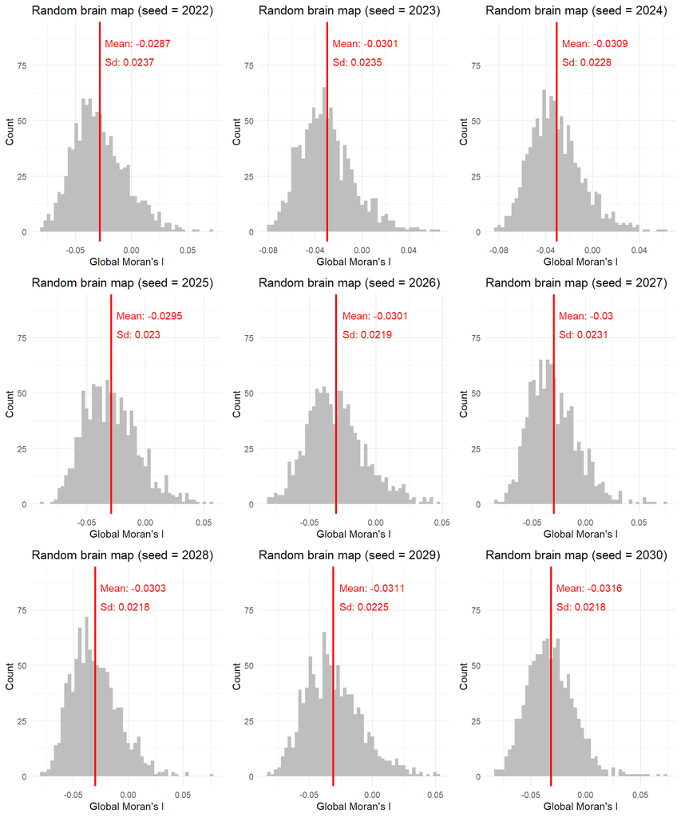

```r
plist=list()
for (seed in c(2022:2030)) {
  set.seed(seed)
  df = matrix(runif(34 * 1000, min = -1, max = 1), nrow = 34)
  colnames(df)=paste0('null_',c(1:1000))
  df.moran = get_column_moran_idx(df)
  hist_data = hist(df.moran$moran_idx, breaks = 50, plot = FALSE)
  mu = mean(df.moran$moran_idx) # calculate the mean
  s_d=sd(df.moran$moran_idx)
  p=ggplot(data = df.moran, aes(x = moran_idx)) +
    geom_histogram(bins = 50, fill = "grey") +
    geom_vline(xintercept = mu, color = "red", linewidth = 1) +
    annotate("text", x = mu+0.005, y = 85,
             label = paste("Mean:", round(mu, 4)),
             color = "red", hjust = 0) +
    annotate("text", x = mu+0.005, y = 85 * 0.90,
             label = paste("Sd:", round(s_d, 4)),
             color = "red", hjust = 0)+
    ggtitle(sprintf("Random brain map (seed = %s)", seed)) +
    xlab("Global Moran's I") +
    ylab('Count')+
    ylim(c(0,90))+
    theme_minimal()
  plist[[as.character(seed)]] = p
}
grid.arrange(grobs=plist)
```

## 3. Global Moran’s I for brain maps that were simulated using the Gaussian random fields (GRFs) approach.

### Figure S2. Global Moran’s I for brain maps that were simulated using the Gaussian random fields (GRFs) approach. More details about this approach and implementation can be found in previous studies (Burt, et al., 2020; Markello and Misic, 2021). Briefly, for each simulated brain map, the two dense, three-dimensional GRFs were created and the level of spatial autocorrelation was determined by the slope of the field’s power spectral density (i.e., alpha). Then the generated GRFs were projected onto the fsaverage5 and the Desikan data on the left hemisphere was extracted. The subplots show the results of three simulations with different power spectral density as measured by alpha. The histogram shows the distributions of the Global Moran’s Is for 1000 simulated brain maps. The vertical line indicates the mean values of the distribution.

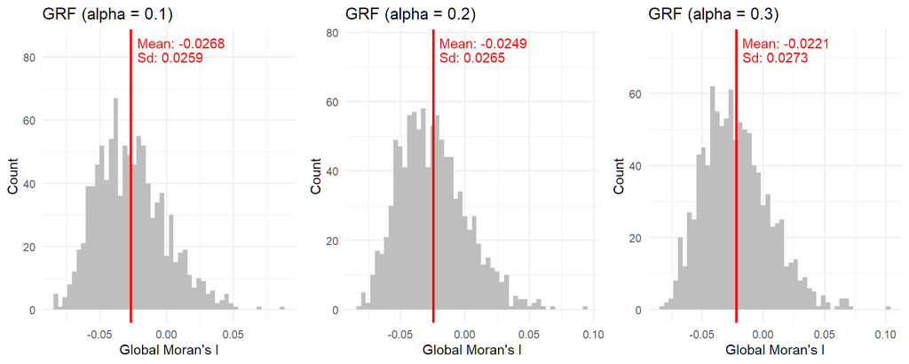

```r
alphas=c(0.1,0.2,0.3)
plist=list()
for (alpha in alphas) {
  df = read.csv(sprintf('%s/random_brain_maps/alpha%s_lh_simbrain_DK.csv', code_path,alpha),
                 row.names = 1)

  df.moran = get_column_moran_idx(df)

  hist_data = hist(df.moran$moran_idx, breaks = 50, plot = FALSE)
  mu = mean(df.moran$moran_idx) # calculate the mean
  s_d=sd(df.moran$moran_idx)
  p=ggplot(data = df.moran, aes(x = moran_idx)) +
    geom_histogram(bins = 50, fill = "grey") +
    geom_vline(xintercept = mu, color = "red", linewidth = 1) +
    annotate("text", x = mu+0.005, y = max(hist_data$counts) * 0.95,
             label = paste("Mean:", round(mu, 4)),
             color = "red", hjust = 0) +
    annotate("text", x = mu+0.005, y = max(hist_data$counts) * 0.90,
             label = paste("Sd:", round(s_d, 4)),
             color = "red", hjust = 0)+
    ggtitle(sprintf("GRF (alpha = %s)", alpha)) +
    xlab("Global Moran's I") +
    ylab('Count')+
    theme_minimal()
  plist[[as.character(alpha)]] = p
  }
grid.arrange(grobs=plist,ncol=3)
```

## 4. Global Moran’s Is for brain maps that were simulated using the subsampling approach.

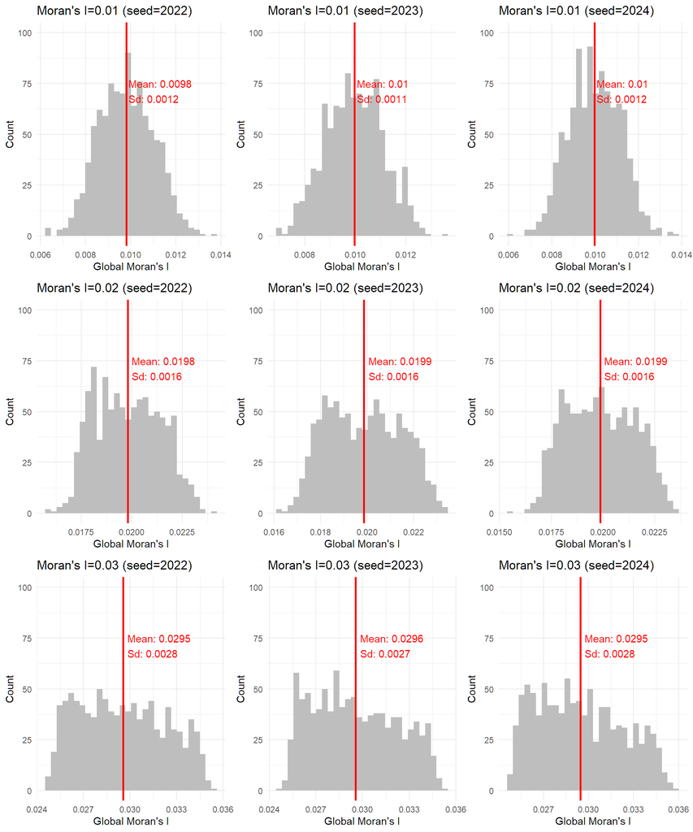

```r
plist=list()
for (moran2sim in c(0.01,0.02,0.03)){
  for (seed in c(2022, 2023, 2024)){
  df = read.csv(sprintf('F:/Google Drive/post-doc/vitural_histology_revisit/new_code/random_brain_maps/moran_%s_lh_simbrain_DK_seed%s.csv',moran2sim,seed),
                row.names = 1)

  df.moran = get_column_moran_idx(df)
  hist_data = hist(df.moran$moran_idx, breaks = 30, plot = FALSE)
  mu = mean(df.moran$moran_idx) # calculate the mean
  s_d=sd(df.moran$moran_idx)
  p=ggplot(data = df.moran, aes(x = moran_idx)) +
    geom_histogram(bins = 30, fill = "grey") +
    geom_vline(xintercept = mu, color = "red", linewidth = 1) +
    annotate("text", x = mu*1.01, y = 75,
             label = paste("Mean:", round(mu, 4)),
             color = "red", hjust = 0) +
    annotate("text", x = mu*1.01, y = 75 * 0.90,
             label = paste("Sd:", round(s_d, 4)),
             color = "red", hjust = 0)+
    ggtitle(sprintf("Moran's I=%s (seed=%s)",moran2sim,seed)) +
    xlab("Global Moran's I") +
    ylab('Count')+
    ylim(c(0,100))+
    theme_minimal()
  plist[[paste0(moran2sim,seed)]] = p
  }
}
grid.arrange(grobs=plist,ncol=3)
```